# Allrecipes_web_scrape

2024-11-22

```r
library(rvest)
library(dplyr)
```

```r
library(ggplot2)
library(tidyr)
```

## Website Choose

Allrecipes is a globally renowned community-driven culinary website, established in 1997 and originally named CookieRecipe.com. The platform brings together home cooks from around the world to share and exchange their recipes, cooking techniques, and experiences. I will scrape the nutritional content data of popular beef dishes from this website.

## Scrape Process

Define a function to loop through the webpage and extract the nutritional content of beef-related dishes that are uniformly listed and recorded.

```r
scrape_nutrition_value <- function(links) {
  nutrition_values <- list()
  for (link in links) {
   page <- read_html(link)
   values <- page %>%
      html_elements("span.mm-recipes-nutrition-facts-label__nutrient-name--has-postfix") %>%  # navigate to <span>
      html_nodes(xpath = "./following-sibling::text()") %>%  # Retrieve adjacent text nodes
      html_text()
   nutrition_values <- c(nutrition_values, list(values))
  }
  return(do.call(c, nutrition_values))
}
```

Define a function to loop through the webpage and extract the dish names.

```r
scrape_headers <- function(links) {
  headers <- c()
  for (link in links) {
    page <- read_html(link)
    header <- page %>%
      html_elements("h1.article-heading.text-headline-400") %>%
      html_text()
    headers <- c(headers, header)
  }
  return(headers)
}
```

Scrape the links of the selected pages (dishes with beef as the main ingredient).

```r
page_one <- "https://www.allrecipes.com/recipes/200/meat-and-poultry/beef/"
page <- read_html(page_one)
links <- page %>%
  html_elements("#tax-sc__recirc-list_1-0 a") %>%
  html_attr("href")
```

Call the scraping function to perform the data extraction mentioned above.

```r
headers_name <- scrape_headers(links)
nutrition_data <- scrape_nutrition_value(links)
```

Scrape the types of nutrition listed for the dishes on the website to later organize them into a table as column names for the nutritional content of the dishes.

```r
page <- "https://www.allrecipes.com/beef-and-bean-tiny-tacos-recipe-8727881" %>%
  read_html(page_one)
nutrition_name <- html_elements(page, "div.mm-recipes-nutrition-facts-label__contents table tbody tr td span") %>%
  html_text()
df_column <- c("Cuisine name", nutrition_name)
```

Organize the scraped data and process it into a table format suitable for subsequent visualization.

```r
# initialize an empty dataframe
df <- data.frame(matrix(ncol = length(df_column), nrow = ceiling(length(nutrition_data) / length(nutrition_name))))
colnames(df) <- df_column

# populate the first column with headers_name
df[, 1] <- headers_name

# fill in the remaining nutritional data
for (i in seq_len(nrow(df))) {
  if (length(nutrition_data) >= (i - 1) * length(nutrition_name) + length(nutrition_name)) {
    # dynamically insert values (each group of values should match the length of nutrition_name)
    df[i, 2:ncol(df)] <- nutrition_data[((i - 1) * length(nutrition_name) + 1):(i * length(nutrition_name))]
  } else {
    df[i, 2:ncol(df)] <- NA  #  if there are not enough values, fill with NA
  }
}
```

Process the data format of certain parts of the dataframe to prepare it for visualization.

```r
for (col in 2:ncol(df)) {  # skip the first column since it represents the dish name.
  df[[col]] <- as.integer(gsub("[^0-9]", "", df[[col]]))
}
for (i in 2:ncol(df)) {
  first_value <- df[1, i]
  if (first_value >= 100 | first_value == 4 ) {
    colnames(df)[i] <- paste0(colnames(df)[i], "(mg)")
  } else {
    colnames(df)[i] <- paste0(colnames(df)[i], "(g)")
  }
}
cleaned_nutrition_df <- df
cleaned_nutrition_df
```

```
##                             Cuisine name Total Fat(g) Saturated Fat(g)
## 1          French Onion Beef and Noodles           23                8
## 2 Tex-Mex Ground Beef and Potato Skillet           59               17
## 3               Beef and Bean Tiny Tacos           51               10
## 4 Bobotie (South African Beef Casserole)           27               10
## 5                        The Crustburger           56               24
## 6                Italian Steak Pizzaiola           33               11
## 7                    Classic Swiss Steak           22                7
## 8        Slow Cooker Stuffed Pepper Soup           14                5
##   Cholesterol(mg) Sodium(mg) Total Carbohydrate(g) Dietary Fiber(g)
## 1             117        536                    31                2
## 2             114       1698                    65                7
## 3              52       1024                    67                5
## 4             155        580                    13                2
## 5             167       2248                    58                4
## 6              88        615                    12                3
## 7             129       1002                    33                4
## 8              58        966                    18                3
##   Total Sugars(g) Protein(g) Vitamin C(mg) Calcium(mg) Iron(mg) Potassium(mg)
## 1               5         34             4         168        4           465
## 2               5         40            46         327        5          1409
## 3               1         24            26         169        3          1630
## 4               4         36             7         137        5           654
## 5              16         47             3        1358        6          1018
## 6               6         30            23          56        4           789
## 7               8         45            29          81        7           915
## 8               6         23            47         141        3           732
```

## Data Visualization & Data Analysis

- **Comparison of the main nutritional content of each dish**

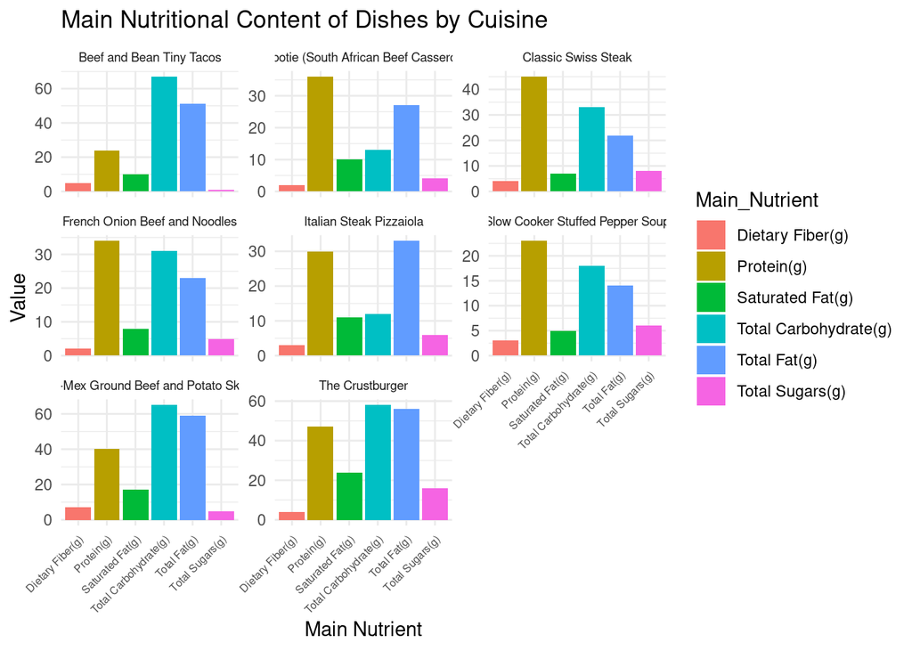

```r
long_data <- cleaned_nutrition_df %>%
  pivot_longer(
    cols = c(`Total Fat(g)`, `Saturated Fat(g)`, `Total Carbohydrate(g)`, `Dietary Fiber(g)`, `Total Sugars(g)`, `Protein(g)`),
    names_to = "Main_Nutrient",
    values_to = "Value"
  )

ggplot(long_data, aes(x = Main_Nutrient, y = Value, fill = Main_Nutrient)) +
  geom_bar(stat = "identity") +
  facet_wrap(~ `Cuisine name`, scales = "free_y") +
  theme_minimal() +
  labs(
    title = "Main Nutritional Content of Dishes by Cuisine",
    x = "Main Nutrient",
    y = "Value"
  ) +
  theme(axis.text.x = element_text(angle = 45, hjust = 1, size = 6),
        strip.text = element_text(size = 7))
```

- **Calorie comparison between different dishes (based on fat data)**

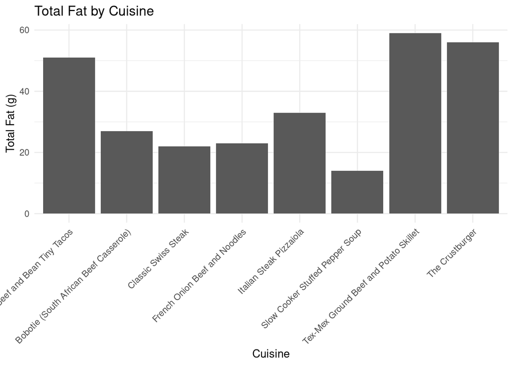

```r
fat_data <- cleaned_nutrition_df %>%
  ggplot(aes(x = `Cuisine name`, y = `Total Fat(g)`)) +
  geom_bar(stat = "identity") +
  theme_minimal() +
  labs(title = "Total Fat by Cuisine", x = "Cuisine", y = "Total Fat (g)") +
  theme(axis.text.x = element_text(angle = 45, hjust = 1))

print(fat_data)
```

- **The Healthiness Of Dishes (based on their sodium and fat content)**

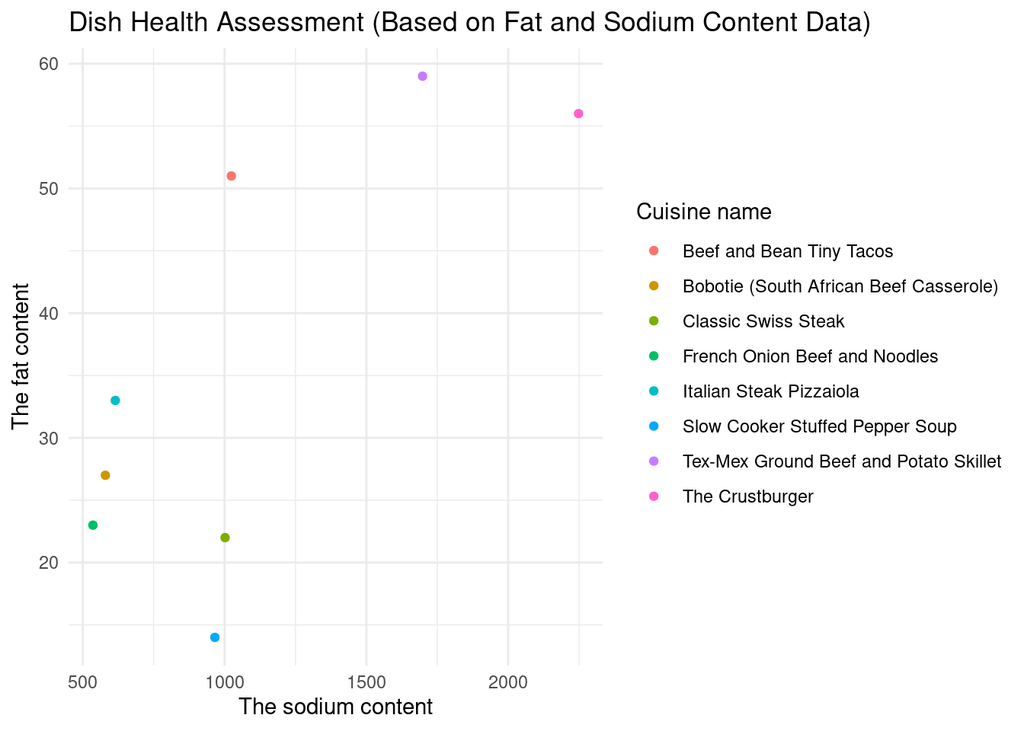

```r
health <- cleaned_nutrition_df %>%
  ggplot(aes(x = `Sodium(mg)`, y = `Total Fat(g)`, color = `Cuisine name`)) +
  geom_point() +
  theme_minimal() +
  labs(title = "Dish Health Assessment (Based on Fat and Sodium Content Data)", x = "The sodium content", y = "The fat content")

print(health)
```

High fat and sodium content in food can potentially pose health risks when consumed in excessive amounts. High fat intake, particularly saturated and trans fats, is associated with increased risks of obesity, cardiovascular diseases, and high cholesterol levels. Similarly, excessive sodium consumption is linked to high blood pressure, heart disease, and stroke. Based on the scatter plot, some dishes, such as “The Crustburger,” stand out with significantly high fat and sodium levels, indicating they may be less healthy options. In contrast, dishes like “Slow Cooker Stuffed Pepper Soup,” with lower fat and sodium content, appear to be healthier choices. The chart highlights the variation in nutritional profiles across dishes and cuisines, emphasizing the need for mindful selection of meals to promote better health outcomes.

## Reflection

While completing this assignment, I found the most challenging part was organizing the scraped data into a well-structured format for storage. Although the data volume was not large, I often found myself getting confused when using for loops to repeatedly add data to the dataframe. I had to rely on AI to help me plan the workflow. Additionally, during the visualization phase, I realized I needed to go back and add more data-cleaning steps, such as transforming data formats, removing units, and appending them to column names. This assignment has been a great practice for my final project, allowing me to develop clearer coding logic and reduce redundant operations in future tasks.